# The Team That Kicks More Wins More

Harry Williams

08/01/2021

# 1 Introduction

During the Autumn Nations Cup in November 2020, Eddie Jones was questioned on his team’s decision to kick the ball more in matches. He answered:“The teams that kick the most win games”.[^1] This report will examine match data from the last three years and showcase the evidence and possible explanations behind the correlation between kicking frequency and win rate.

## 1.1 The Data

### 1.1.1 Competitions

Data has been sourced from the Rugby Pass website.[^2] At time of writing this includes a total of 619 professional global Rugby matches over the last 3 years. This includes both international and club rugby games from the following competitions:

| Competition | Type Of Team | Hemisphere |
| --- | --- | --- |
| Autumn Nations Cup | International | Northern |
| Currie Cup | Club | Southern |
| European Champions Cup | Club | Northern |
| Internationals | International | Mixed |
| Mitre 10 Cup | Club | Southern |
| Premiership | Club | Northern |
| Premiership Cup | Club | Northern |
| Pro 14 | Club | Northern |
| Rugby World Cup | International | Mixed |
| Six Nations | International | Northern |
| Super Rugby | Club | Southern |
| Super Rugby Aotearoa | Club | Southern |
| Super Rugby Australia | Club | Southern |
| Super Rugby Unlocked | Club | Southern |
| The Rugby Championship | International | Southern |
| Top 14 | Club | Northern |

### 1.1.2 Variables

The variables collected from each match are as follows:

| Ball Carry | Line Break | Penalty Goal Successful | Scrum Won |
| --- | --- | --- | --- |
| Ball Carry Meters | Lineout Throw Won Clean | Penalty Missed | Tackle Made |
| Beat Defender | Lineout Won Own Throw | Points Scored | Tackle Missed |
| Conversion Missed | Lineout Won Steal | Possession | Total Turnovers Conceded |
| Conversion Successful | Mauls Won | Red Card | Total Turnovers Gained |
| Drop Goal Missed | Offload | Rucks Lost | Try Assist |
| Drop Kick Successful | Passes | Rucks Won | Try Scored |
| Kicks From Hand | Penalties Conceded | Scrum Lost | Yellow Card |

### 1.1.3 Three Key Variables

The first key variable explored in this investigation is `Kicks From Hand`. This is the total number of kicks in play but does not include penalty kicks. `Win Rate` is the second key variable explored, and can be defined as the percentage number of wins for a team. Finally `Kick Rate`, which is the percentage number of times a team has kicked more than their opposition. `Win Rate` and `Kick Rate` have been calculated in the following ways:

$$Win\:Rate = \frac{Number\:of\:Matches\:Won}{Total\:Matches\:Played}$$

$$Kick\:Rate = \frac{Number\:of\:Times\:Kicked\: More\: Than\: Opposition}{Total\:Matches\:Played}$$

### 1.1.4 Data Limitions

#### 1.1.4.1 Rugby Pass Data

| Year | Count |
| --- | --- |
| 2018 | 114 |
| 2019 | 152 |
| 2020 | 303 |
| 2021 | 50 |

#### 1.1.4.2 Variable Limitions

`Kicks From Hand` only includes the total number of kicks made in each match. The dataset does not give a more precise count of different types of kicks in a match. Tactically, a kick from a team’s own 22 is very different from a kick from the halfway line or inside the opposition’s half. A breakdown of the number of kicks by territory would better reflect this. This can also be applied to penalties as it is difficult to determine how each penalty was conceded e.g. from the breakdown or scrum. This data would offer a much more detailed analysis than what the current dataset allows.

# 2 Analysis

## 2.1 Teams that kicks more than the opposition

### 2.1.1 Percentage Number of Match Wins

Using the data, the percentage number of wins for teams that kick more than their opponents are as follows:

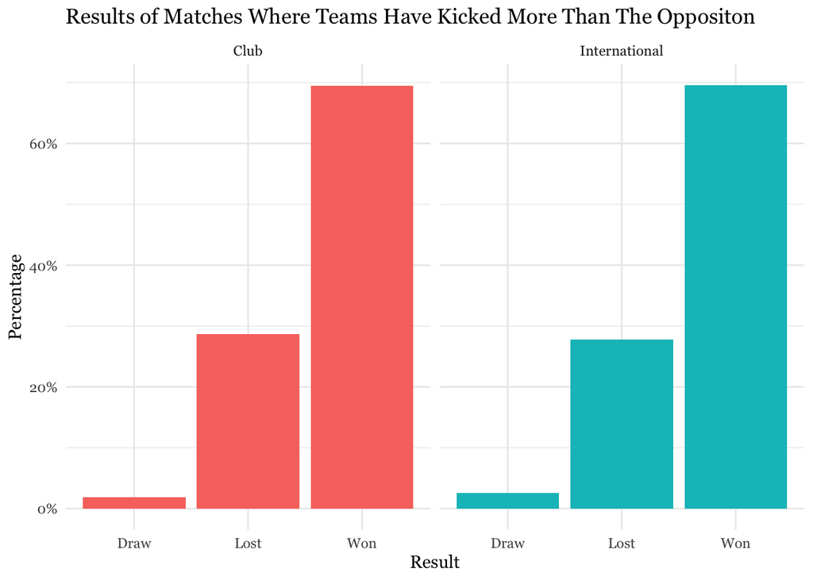

This graph shows the results when a team has kicked more than the opposition, split over both club and international games. The data shows that teams that kick more frequently than their opponents won around 69% of their matches.

### 2.1.2 Hypothesis Test

Since this dataset is a sample, a hypothesis test needs to be carried out to confirm if 69% is representative across all professional matches. The method for the test can be found in the dropdown.

**Hypothesis Test**

If kicking had no impact on the win rate of matches, the expected proportion of matches won would be around 50%. A hypothesis test can be used to see if the dataset reflects the whole population or simply sampling variation.

The Hypothesis test can be defined as follows:

H<sub>0</sub>: π matches won = 0.5

H<sub>A</sub>: π matches won > 0.5

α = 0.05

When looking at teams that kick more than their opposition, if the p-value is greater than 0.05 then we accept H<sub>0</sub>. We can then conclude that the proportion of the number of matches won should be around 50%. If the p-value is less than 0.05 then H<sub>0</sub> is rejected in favour of H<sub>A</sub>. If this is the case, we can then conclude that the proportion of the number of matches won is greater than 50%.

```r
tset_matches_sample <- test_matches

null_distribution <- tset_matches_sample %>%
  specify(response = won, success = "TRUE") %>%
  hypothesize(null = "point", p = 0.5) %>%
  generate(reps = 10000, type = "simulate") %>%
  calculate(stat = "prop")

observed_stat <- tset_matches_sample %>%
  specify(response = won, success = "TRUE") %>%
  calculate(stat = "prop")
```

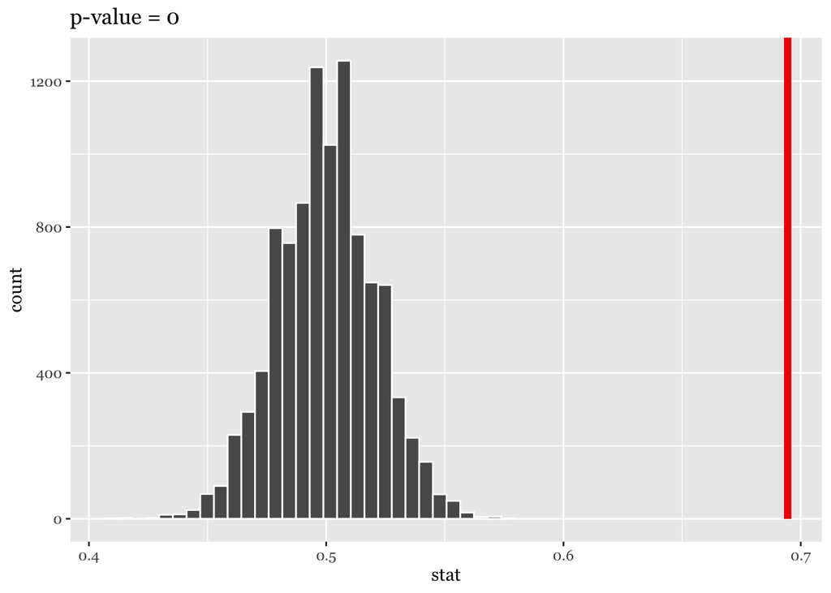

```r
  p_value <- null_distribution %>%
  get_p_value(obs_stat = observed_stat, direction = "both")


null_distribution %>%
  visualise(bins = 30) +
  shade_p_value(obs_stat = observed_stat, direction = "right") +
  labs(title = paste("p-value =", p_value ))+
  theme(text = element_text(family = "Georgia"))
```

The p-value is less than α, so H<sub>0</sub> is rejected in favour of H<sub>A</sub>. There is enough evidence from the data to suggest that the proportion of wins is statistically significantly greater than the null value. This means that statistically, teams that kick more than their opponents win a larger proportion of their games.

### 2.1.3 Results of the test

The hypothesis test has shown that there is enough evidence from this dataset to reliably conclude that teams that kick more than their opponent will win more of their games.

A further computation can be carried out to give a percentage range within a 95% confidence interval of the population.

### 2.1.4 Estimated Percentage Wins

| Lower Confidence Interval | Upper Confidence Interval |
| --- | --- |
| 65.7% | 73.21% |

From this dataset, it is estimated that teams that kick more than their opponents win between 65.7% - 73.21% of their total matches within a 95% confidence interval.

## 2.2 Win Rate vs Kick Rate

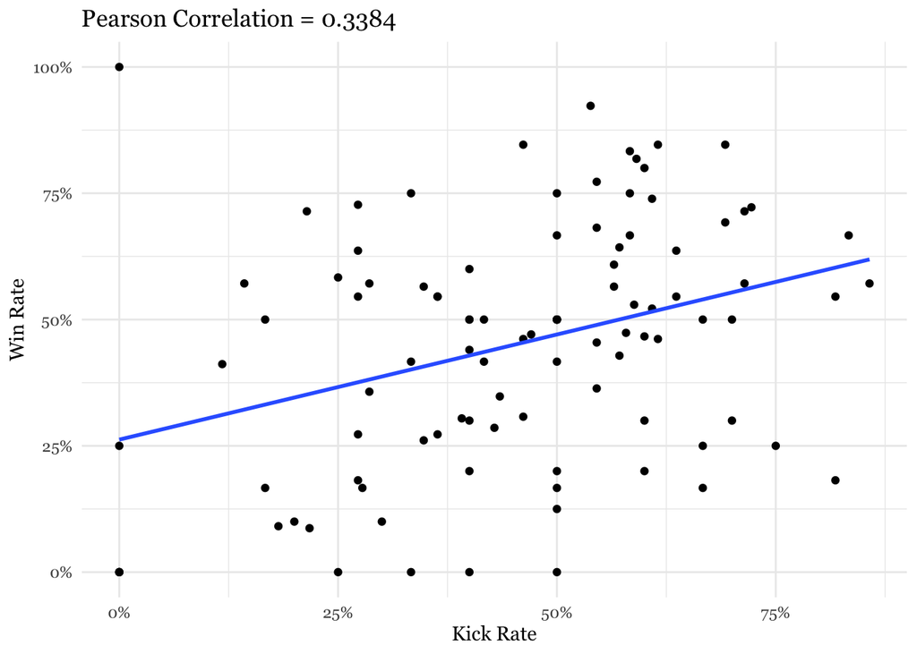

Plotting `Win Rate` and `Kick Rate` there is a moderate correlation of 0.3384. While there is quite a lot of spread within the data, there is still a general trend: teams that have a higher kick rate also have a higher win rate. As there is a moderate correlation, other variables can also be used to explain `Win Rate`.

## 2.3 Win Rate vs Average Number of Kicks per Game

### 2.3.1 Top 10 teams by Average Number of Kicks per Game

| Rank | Team | Avg. No. Kicks Per Game | Draw | Lost | Won | Win Rate |
| --- | --- | --- | --- | --- | --- | --- |
| 1 | Western Force | 37.12 | 0 | 8 | 0 | 0% |
| 2 | England | 30.77 | 1 | 4 | 17 | 77.27% |
| 3 | France | 28.94 | 0 | 8 | 9 | 52.94% |
| 4 | Harlequins | 28.27 | 1 | 4 | 6 | 54.55% |
| 5 | Newcastle Falcons | 27.29 | 0 | 3 | 4 | 57.14% |
| 6 | South Africa | 26.31 | 1 | 3 | 9 | 69.23% |
| 7 | Wales | 26.18 | 0 | 4 | 18 | 81.82% |
| 8 | Benetton Treviso | 26.10 | 0 | 10 | 0 | 0% |
| 9 | Leicester Tigers | 25.71 | 0 | 3 | 4 | 57.14% |
| 10 | Scotland | 25.58 | 1 | 9 | 9 | 47.37% |

The split can be shown as follows:

| Type Of Team | Avg. No. Kicks Per Games |
| --- | --- |
| Club | 20.27 |
| International | 23.65 |

### 2.3.2 Win Rate vs Average Number of Kicks per Game Plot

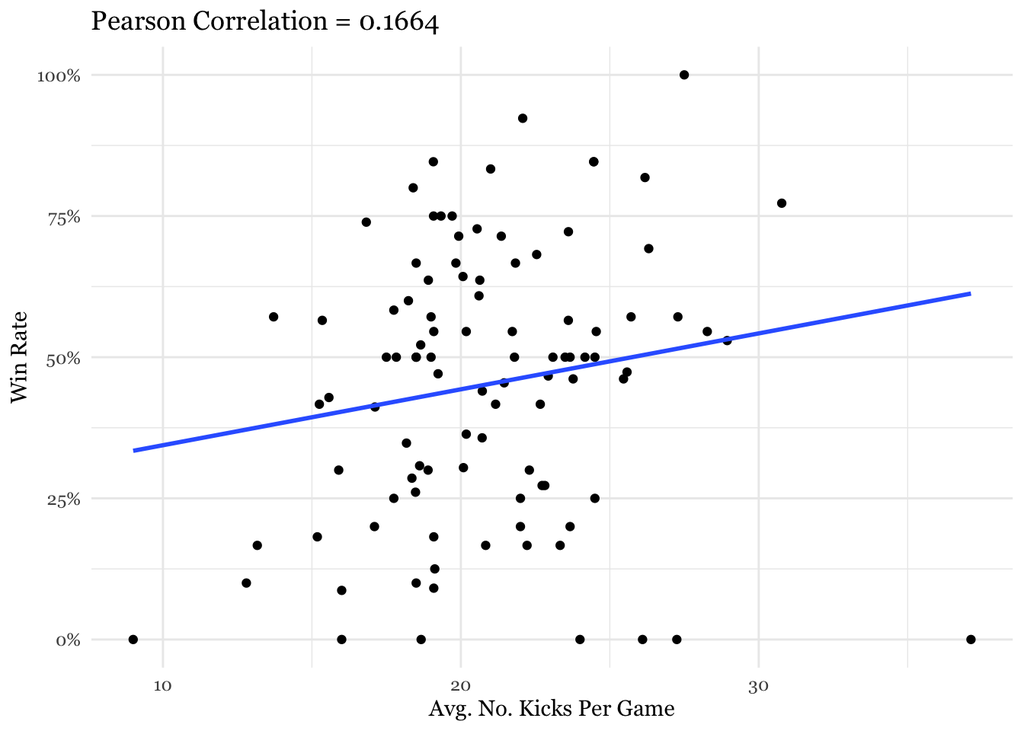

## 2.4 Further Exploration

As the data is more complete when looking at international matches, this exploration will now only focus on the international game.

### 2.4.1 Correlation with `Kicks From Hand`

Below is a graph showing which other variables correlate with `Kicks From Hand`:

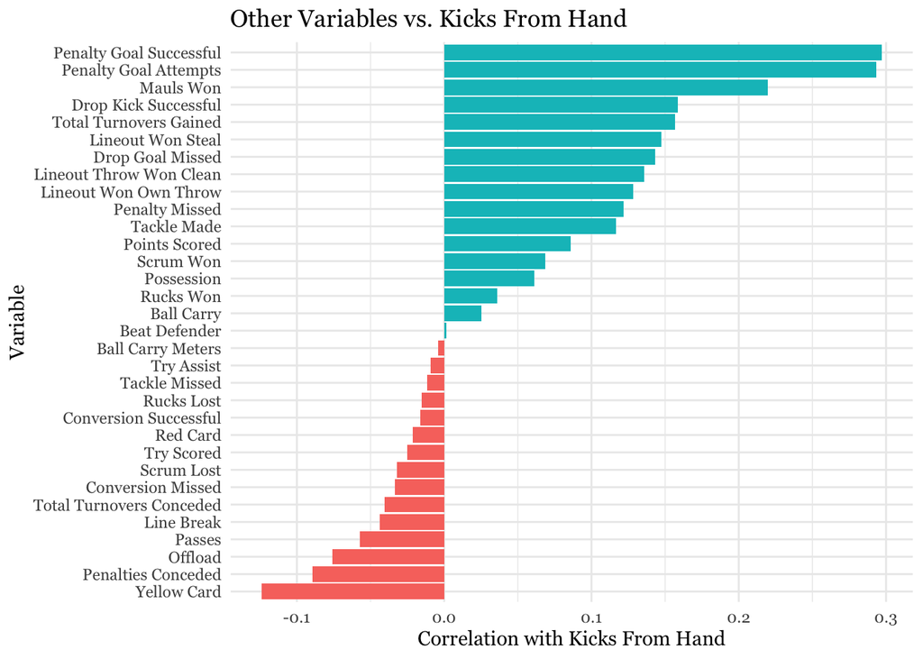

Any correlation score over 0.2 is weak. There appears to be a weak correlation between the number of `Kicks from Hand` and the number of `Penalty Goal Successful` and `Penalty Goal Attempts`. This could explain some of the reasons why teams that kick more than their opponent have a higher chance of winning.

Unfortunately the data variables are not suited to make an accurate model to explain this link. However, the data can offer some insight by highlighting key variables within an explanatory model.

### 2.4.2 Explanatory Model

**Model Construction**

Penalty Goal Successful and team both look like good options

```r
mod1a <- lm(kicks_from_hand ~ team, data = model_data)
```

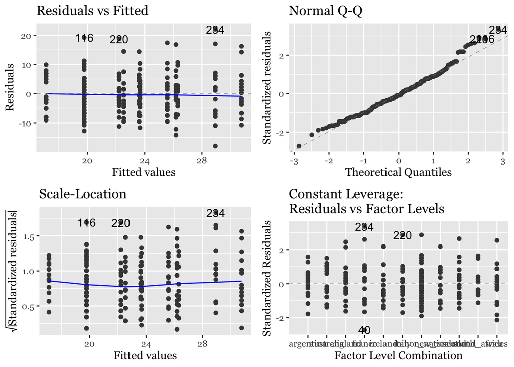

```r
autoplot(mod1a) +
  theme(text = element_text(family = "Georgia"))
```

```r
summary(mod1a)
```

```
##
## Call:
## lm(formula = kicks_from_hand ~ team, data = model_data)
##
## Residuals:
##      Min       1Q   Median       3Q      Max
## -17.9412  -4.4860  -0.5789   4.2182  22.0588
##
## Coefficients:
##                  Estimate Std. Error t value Pr(>|t|)
## (Intercept)        17.118      1.646  10.399  < 2e-16 ***
## teamnew_zealand     6.493      2.295   2.829 0.005089 **
## teamengland        13.655      2.192   6.230 2.24e-09 ***
## teamsouth_africa    9.190      2.501   3.675 0.000297 ***
## teamireland         5.428      2.192   2.477 0.013997 *
## teamitaly           5.105      2.295   2.224 0.027145 *
## teamminor_nation    2.664      1.883   1.415 0.158574
## teamscotland        8.461      2.266   3.734 0.000238 ***
## teamwales           9.064      2.192   4.136 4.98e-05 ***
## teamfrance         11.824      2.328   5.079 7.91e-07 ***
## teamargentina       6.549      2.404   2.724 0.006954 **
## ---
## Signif. codes:  0 '***' 0.001 '**' 0.01 '*' 0.05 '.' 0.1 ' ' 1
##
## Residual standard error: 6.787 on 227 degrees of freedom
## Multiple R-squared:  0.2512, Adjusted R-squared:  0.2182
## F-statistic: 7.614 on 10 and 227 DF,  p-value: 1.844e-10
```

As with the top 10 teams with the highest average kicks per game, England, France, South Africa, Wales contribute towards kicking more in matches

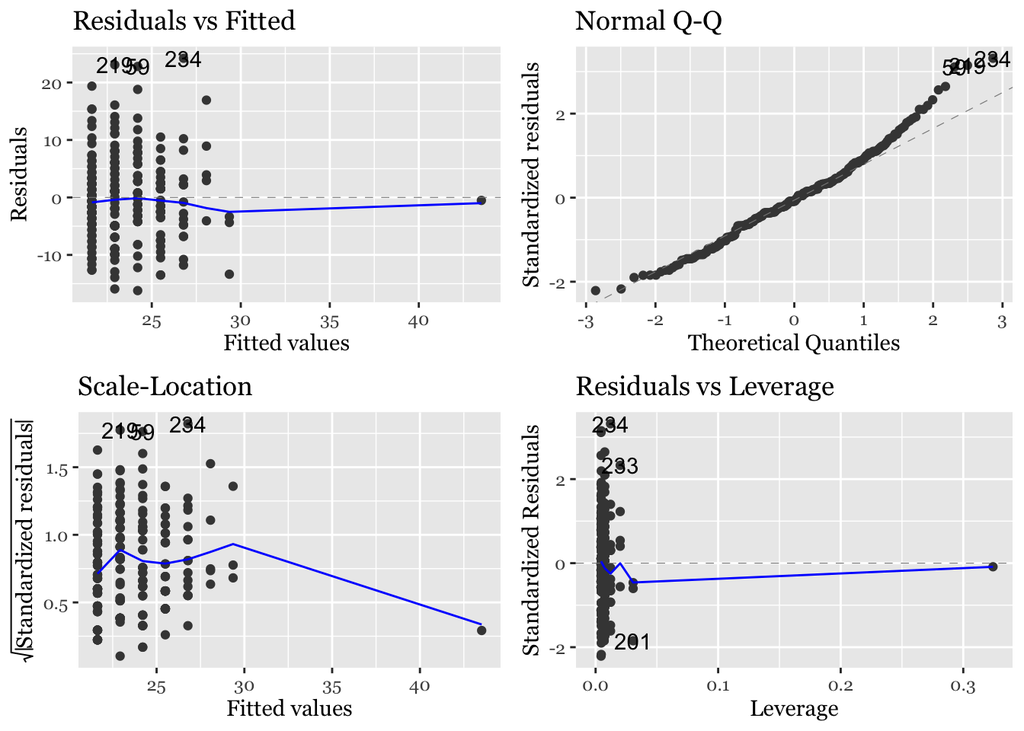

```r
mod1b <- lm(kicks_from_hand ~ penalty_goal_successful, data = model_data)

autoplot(mod1b) +
  theme(text = element_text(family = "Georgia"))
```

```r
summary(mod1b)
```

```
##
## Call:
## lm(formula = kicks_from_hand ~ penalty_goal_successful, data = model_data)
##
## Residuals:
##      Min       1Q   Median       3Q      Max
## -16.2095  -4.6353  -0.5754   3.7905  24.2164
##
## Coefficients:
##                         Estimate Std. Error t value Pr(>|t|)
## (Intercept)              21.6353     0.6353  34.053  < 2e-16 ***
## penalty_goal_successful   1.2871     0.2692   4.782 3.06e-06 ***
## ---
## Signif. codes:  0 '***' 0.001 '**' 0.01 '*' 0.05 '.' 0.1 ' ' 1
##
## Residual standard error: 7.345 on 236 degrees of freedom
## Multiple R-squared:  0.08832,    Adjusted R-squared:  0.08446
## F-statistic: 22.86 on 1 and 236 DF,  p-value: 3.062e-06
```

mod1a has the highest r^2 so that will be used.

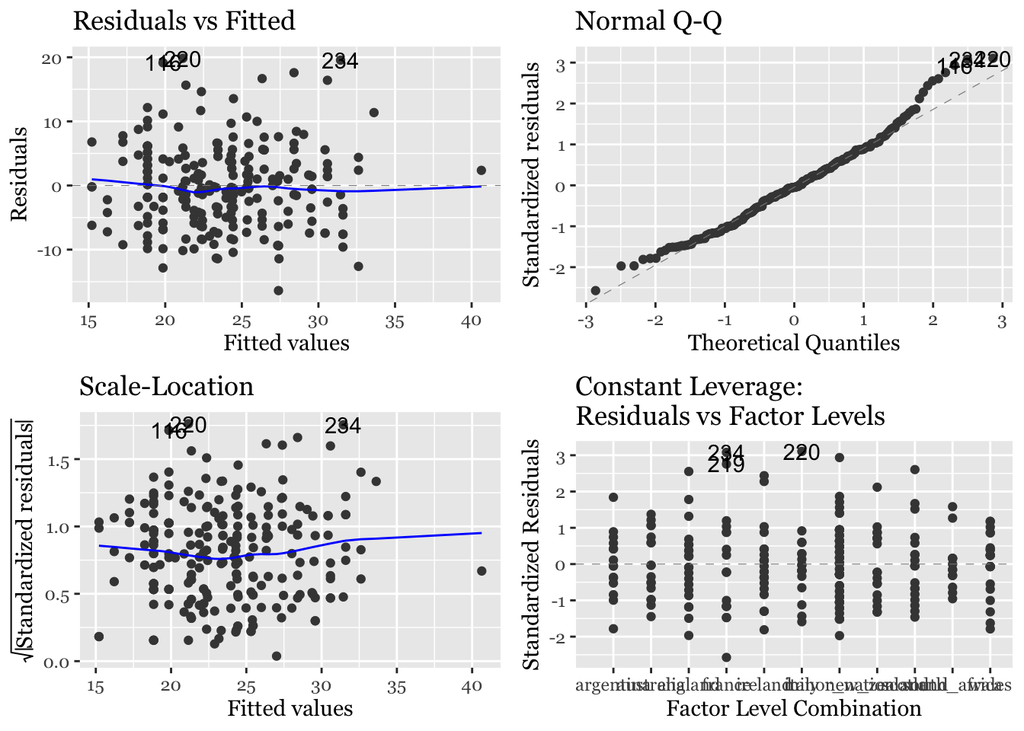

```r
mod2a <- lm(kicks_from_hand ~ team + penalty_goal_successful, data = model_data)

autoplot(mod2a)+
  theme(text = element_text(family = "Georgia"))
```

```r
summary(mod2a)
```

```
##
## Call:
## lm(formula = kicks_from_hand ~ team + penalty_goal_successful,
##     data = model_data)
##
## Residuals:
##      Min       1Q   Median       3Q      Max
## -16.3922  -4.4051  -0.3124   3.7876  19.8468
##
## Coefficients:
##                         Estimate Std. Error t value Pr(>|t|)
## (Intercept)              15.2113     1.6679   9.120  < 2e-16 ***
## teamnew_zealand           7.2183     2.2331   3.232 0.001411 **
## teamengland              13.3518     2.1263   6.279 1.72e-09 ***
## teamsouth_africa          8.7593     2.4269   3.609 0.000378 ***
## teamireland               6.1373     2.1326   2.878 0.004388 **
## teamitaly                 5.9419     2.2356   2.658 0.008426 **
## teamminor_nation          3.6314     1.8425   1.971 0.049954 *
## teamscotland              9.0884     2.2026   4.126 5.19e-05 ***
## teamwales                 8.2085     2.1360   3.843 0.000158 ***
## teamfrance               12.1810     2.2589   5.392 1.75e-07 ***
## teamargentina             6.0923     2.3340   2.610 0.009652 **
## penalty_goal_successful   1.0128     0.2573   3.935 0.000111 ***
## ---
## Signif. codes:  0 '***' 0.001 '**' 0.01 '*' 0.05 '.' 0.1 ' ' 1
##
## Residual standard error: 6.58 on 226 degrees of freedom
## Multiple R-squared:  0.2992, Adjusted R-squared:  0.2651
## F-statistic: 8.772 on 11 and 226 DF,  p-value: 6.334e-13
```

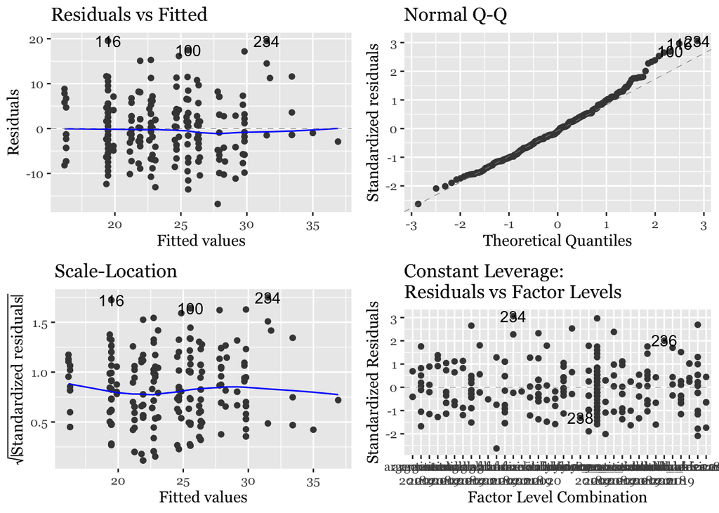

```r
mod2b <- lm(kicks_from_hand ~ team + year, data = model_data)

autoplot(mod2b)+
  theme(text = element_text(family = "Georgia"))
```

```r
summary(mod2b)
```

```
##
## Call:
## lm(formula = kicks_from_hand ~ team + year, data = model_data)
##
## Residuals:
##      Min       1Q   Median       3Q      Max
## -16.7899  -4.3344  -0.6045   3.5246  19.5246
##
## Coefficients:
##                  Estimate Std. Error t value Pr(>|t|)
## (Intercept)       16.1792     1.8141   8.919  < 2e-16 ***
## teamnew_zealand    6.5456     2.2481   2.912 0.003959 **
## teamengland       13.5184     2.1533   6.278 1.76e-09 ***
## teamsouth_africa  10.0438     2.4648   4.075 6.39e-05 ***
## teamireland        5.6133     2.1483   2.613 0.009587 **
## teamitaly          4.9557     2.2568   2.196 0.029124 *
## teamminor_nation   3.1738     1.8562   1.710 0.088674 .
## teamscotland       8.3632     2.2277   3.754 0.000222 ***
## teamwales          9.2496     2.1483   4.306 2.49e-05 ***
## teamfrance        11.6107     2.2900   5.070 8.32e-07 ***
## teamargentina      6.4321     2.3548   2.732 0.006807 **
## year2019           0.1223     1.1111   0.110 0.912427
## year2020           3.7130     1.4560   2.550 0.011433 *
## year2021           7.2088     3.5205   2.048 0.041759 *
## ---
## Signif. codes:  0 '***' 0.001 '**' 0.01 '*' 0.05 '.' 0.1 ' ' 1
##
## Residual standard error: 6.646 on 224 degrees of freedom
## Multiple R-squared:  0.2915, Adjusted R-squared:  0.2504
## F-statistic:  7.09 on 13 and 224 DF,  p-value: 1.679e-11
```

mod2a has the highest r^2 so is the best option

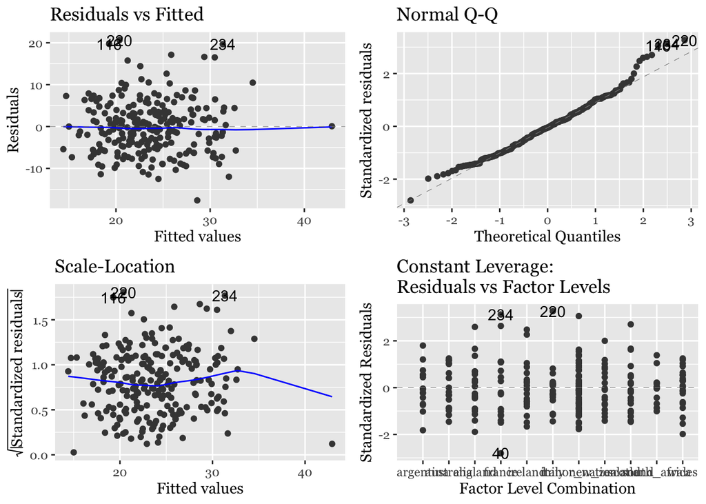

```r
mod3a <- lm(kicks_from_hand ~ team + penalty_goal_successful + lineout_won_own_throw, data = model_data)

autoplot(mod3a)+
  theme(text = element_text(family = "Georgia"))
```

```r
summary(mod3a)
```

```
##
## Call:
## lm(formula = kicks_from_hand ~ team + penalty_goal_successful +
##     lineout_won_own_throw, data = model_data)
##
## Residuals:
##      Min       1Q   Median       3Q      Max
## -17.6275  -4.3716  -0.3014   3.7792  20.6253
##
## Coefficients:
##                         Estimate Std. Error t value Pr(>|t|)
## (Intercept)              11.7451     2.2160   5.300 2.76e-07 ***
## teamnew_zealand           7.6796     2.2199   3.459 0.000647 ***
## teamengland              13.6826     2.1102   6.484 5.59e-10 ***
## teamsouth_africa          8.7924     2.4032   3.659 0.000316 ***
## teamireland               6.2344     2.1121   2.952 0.003494 **
## teamitaly                 6.2590     2.2178   2.822 0.005197 **
## teamminor_nation          4.4084     1.8543   2.377 0.018270 *
## teamscotland              9.3591     2.1841   4.285 2.71e-05 ***
## teamwales                 8.6141     2.1221   4.059 6.80e-05 ***
## teamfrance               12.7339     2.2491   5.662 4.54e-08 ***
## teamargentina             6.0576     2.3111   2.621 0.009363 **
## penalty_goal_successful   1.0485     0.2553   4.107 5.61e-05 ***
## lineout_won_own_throw     0.2963     0.1263   2.346 0.019858 *
## ---
## Signif. codes:  0 '***' 0.001 '**' 0.01 '*' 0.05 '.' 0.1 ' ' 1
##
## Residual standard error: 6.516 on 225 degrees of freedom
## Multiple R-squared:  0.3159, Adjusted R-squared:  0.2795
## F-statistic:  8.66 on 12 and 225 DF,  p-value: 1.67e-13
```

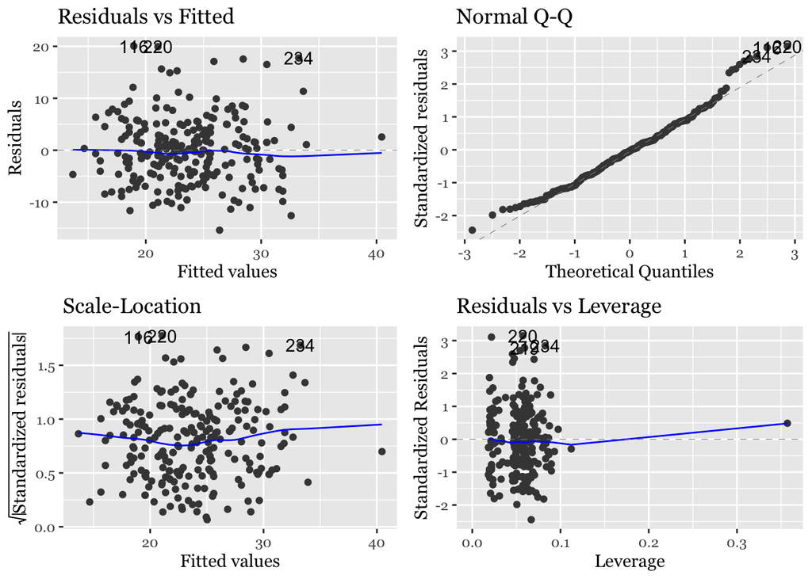

```r
mod3b <- lm(kicks_from_hand~ team + penalty_goal_successful+total_turnovers_gained , data = model_data)

autoplot(mod3b)+
  theme(text = element_text(family = "Georgia"))
```

```r
summary(mod3b)
```

```
##
## Call:
## lm(formula = kicks_from_hand ~ team + penalty_goal_successful +
##     total_turnovers_gained, data = model_data)
##
## Residuals:
##      Min       1Q   Median       3Q      Max
## -15.3959  -4.5835  -0.2033   3.7980  20.0408
##
## Coefficients:
##                         Estimate Std. Error t value Pr(>|t|)
## (Intercept)              12.6869     1.9815   6.403 8.78e-10 ***
## teamnew_zealand           6.9266     2.2156   3.126 0.002004 **
## teamengland              13.3849     2.1063   6.355 1.15e-09 ***
## teamsouth_africa          7.6847     2.4487   3.138 0.001927 **
## teamireland               6.3629     2.1147   3.009 0.002921 **
## teamitaly                 6.7175     2.2399   2.999 0.003013 **
## teamminor_nation          3.8979     1.8288   2.131 0.034139 *
## teamscotland              9.4589     2.1877   4.324 2.31e-05 ***
## teamwales                 8.1733     2.1159   3.863 0.000147 ***
## teamfrance               12.0602     2.2382   5.388 1.79e-07 ***
## teamargentina             6.1209     2.3120   2.647 0.008683 **
## penalty_goal_successful   1.0554     0.2556   4.129 5.13e-05 ***
## total_turnovers_gained    0.3298     0.1429   2.308 0.021925 *
## ---
## Signif. codes:  0 '***' 0.001 '**' 0.01 '*' 0.05 '.' 0.1 ' ' 1
##
## Residual standard error: 6.518 on 225 degrees of freedom
## Multiple R-squared:  0.3154, Adjusted R-squared:  0.2789
## F-statistic: 8.639 on 12 and 225 DF,  p-value: 1.806e-13
```

mod3a has the highest r^2 is the better model going forward.

```r
mod4a <- lm(kicks_from_hand ~ team + penalty_goal_successful + lineout_won_own_throw  + line_break, data = model_data)

summary(mod4a)
```

```
##
## Call:
## lm(formula = kicks_from_hand ~ team + penalty_goal_successful +
##     lineout_won_own_throw + line_break, data = model_data)
##
## Residuals:
##     Min      1Q  Median      3Q     Max
## -17.900  -4.466  -0.351   3.516  19.537
##
## Coefficients:
##                         Estimate Std. Error t value Pr(>|t|)
## (Intercept)             13.01855    2.23898   5.814 2.08e-08 ***
## teamnew_zealand          8.52192    2.21362   3.850 0.000154 ***
## teamengland             14.17731    2.09078   6.781 1.05e-10 ***
## teamsouth_africa         9.08993    2.37421   3.829 0.000167 ***
## teamireland              5.94504    2.08714   2.848 0.004803 **
## teamitaly                6.08910    2.18959   2.781 0.005882 **
## teamminor_nation         4.11223    1.83328   2.243 0.025869 *
## teamscotland             9.70722    2.15934   4.495 1.11e-05 ***
## teamwales                8.66945    2.09434   4.139 4.93e-05 ***
## teamfrance              13.09365    2.22367   5.888 1.42e-08 ***
## teamargentina            5.85786    2.28196   2.567 0.010909 *
## penalty_goal_successful  1.01460    0.25224   4.022 7.88e-05 ***
## lineout_won_own_throw    0.32112    0.12501   2.569 0.010857 *
## line_break              -0.21345    0.08047  -2.652 0.008563 **
## ---
## Signif. codes:  0 '***' 0.001 '**' 0.01 '*' 0.05 '.' 0.1 ' ' 1
##
## Residual standard error: 6.43 on 224 degrees of freedom
## Multiple R-squared:  0.3368, Adjusted R-squared:  0.2983
## F-statistic: 8.749 on 13 and 224 DF,  p-value: 2.236e-14
```

```r
mod4b <- lm(kicks_from_hand ~ team + penalty_goal_successful + lineout_won_own_throw  + total_turnovers_gained, data = model_data)

summary(mod4b)
```

```
##
## Call:
## lm(formula = kicks_from_hand ~ team + penalty_goal_successful +
##     lineout_won_own_throw + total_turnovers_gained, data = model_data)
##
## Residuals:
##      Min       1Q   Median       3Q      Max
## -16.6366  -4.4001  -0.1611   3.5283  20.7482
##
## Coefficients:
##                         Estimate Std. Error t value Pr(>|t|)
## (Intercept)               9.0627     2.4626   3.680 0.000292 ***
## teamnew_zealand           7.3921     2.2002   3.360 0.000917 ***
## teamengland              13.7252     2.0884   6.572 3.44e-10 ***
## teamsouth_africa          7.6898     2.4224   3.174 0.001712 **
## teamireland               6.4686     2.0925   3.091 0.002245 **
## teamitaly                 7.0637     2.2204   3.181 0.001674 **
## teamminor_nation          4.7022     1.8391   2.557 0.011227 *
## teamscotland              9.7466     2.1675   4.497 1.11e-05 ***
## teamwales                 8.5885     2.1002   4.089 6.03e-05 ***
## teamfrance               12.6243     2.2263   5.671 4.36e-08 ***
## teamargentina             6.0861     2.2872   2.661 0.008357 **
## penalty_goal_successful   1.0932     0.2533   4.315 2.39e-05 ***
## lineout_won_own_throw     0.3040     0.1251   2.431 0.015835 *
## total_turnovers_gained    0.3386     0.1414   2.395 0.017463 *
## ---
## Signif. codes:  0 '***' 0.001 '**' 0.01 '*' 0.05 '.' 0.1 ' ' 1
##
## Residual standard error: 6.448 on 224 degrees of freedom
## Multiple R-squared:  0.333,  Adjusted R-squared:  0.2943
## F-statistic: 8.603 on 13 and 224 DF,  p-value: 3.965e-14
```

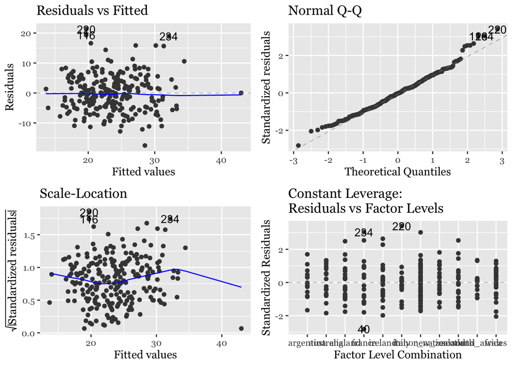

```r
mod4c <- lm(kicks_from_hand ~ team + penalty_goal_successful + lineout_won_own_throw + lineout_won_steal, data = model_data)

autoplot(mod4c)+
  theme(text = element_text(family = "Georgia"))
```

```r
summary(mod4c)
```

```
##
## Call:
## lm(formula = kicks_from_hand ~ team + penalty_goal_successful +
##     lineout_won_own_throw + lineout_won_steal, data = model_data)
##
## Residuals:
##      Min       1Q   Median       3Q      Max
## -17.5191  -4.6423  -0.1724   3.8407  21.2928
##
## Coefficients:
##                         Estimate Std. Error t value Pr(>|t|)
## (Intercept)              10.4665     2.2700   4.611 6.74e-06 ***
## teamnew_zealand           7.6878     2.2005   3.494 0.000574 ***
## teamengland              14.1134     2.1006   6.719 1.50e-10 ***
## teamsouth_africa          8.7204     2.3824   3.660 0.000314 ***
## teamireland               6.7378     2.1057   3.200 0.001574 **
## teamitaly                 6.9149     2.2179   3.118 0.002061 **
## teamminor_nation          5.2618     1.8773   2.803 0.005510 **
## teamscotland             10.1965     2.1972   4.641 5.91e-06 ***
## teamwales                 9.3762     2.1311   4.400 1.68e-05 ***
## teamfrance               13.0874     2.2350   5.856 1.68e-08 ***
## teamargentina             6.3590     2.2949   2.771 0.006058 **
## penalty_goal_successful   1.0346     0.2531   4.087 6.08e-05 ***
## lineout_won_own_throw     0.2907     0.1252   2.321 0.021167 *
## lineout_won_steal         0.8950     0.4007   2.234 0.026500 *
## ---
## Signif. codes:  0 '***' 0.001 '**' 0.01 '*' 0.05 '.' 0.1 ' ' 1
##
## Residual standard error: 6.459 on 224 degrees of freedom
## Multiple R-squared:  0.3308, Adjusted R-squared:  0.292
## F-statistic: 8.519 on 13 and 224 DF,  p-value: 5.509e-14
```

team:penalty_goal_successful

```r
mod5a <- lm(kicks_from_hand ~ team + penalty_goal_successful + lineout_won_own_throw + total_turnovers_gained + team:penalty_goal_successful, data = model_data)

summary(mod5a)
```

```
##
## Call:
## lm(formula = kicks_from_hand ~ team + penalty_goal_successful +
##     lineout_won_own_throw + total_turnovers_gained + team:penalty_goal_successful,
##     data = model_data)
##
## Residuals:
##      Min       1Q   Median       3Q      Max
## -13.0590  -4.6693  -0.4564   3.6089  20.8819
##
## Coefficients:
##                                          Estimate Std. Error t value Pr(>|t|)
## (Intercept)                                7.7515     3.1753   2.441  0.01545
## teamnew_zealand                            6.2994     3.5291   1.785  0.07568
## teamengland                               15.6246     3.6372   4.296 2.64e-05
## teamsouth_africa                           6.8908     4.0709   1.693  0.09197
## teamireland                                8.4772     3.0719   2.760  0.00629
## teamitaly                                  8.3939     3.3051   2.540  0.01181
## teamminor_nation                           7.0461     2.8091   2.508  0.01287
## teamscotland                              11.0012     3.2701   3.364  0.00091
## teamwales                                  9.2529     3.1302   2.956  0.00347
## teamfrance                                10.2156     3.4777   2.937  0.00367
## teamargentina                              6.5366     3.7943   1.723  0.08638
## penalty_goal_successful                    1.6401     1.0771   1.523  0.12929
## lineout_won_own_throw                      0.2964     0.1300   2.280  0.02359
## total_turnovers_gained                     0.3884     0.1433   2.711  0.00725
## teamnew_zealand:penalty_goal_successful    1.2207     1.9250   0.634  0.52666
## teamengland:penalty_goal_successful       -0.9465     1.4767  -0.641  0.52223
## teamsouth_africa:penalty_goal_successful   0.1757     1.5381   0.114  0.90914
## teamireland:penalty_goal_successful       -1.3520     1.3738  -0.984  0.32616
## teamitaly:penalty_goal_successful         -0.7328     1.7260  -0.425  0.67155
## teamminor_nation:penalty_goal_successful  -1.9482     1.2910  -1.509  0.13276
## teamscotland:penalty_goal_successful      -0.6891     1.5478  -0.445  0.65664
## teamwales:penalty_goal_successful         -0.4171     1.1533  -0.362  0.71794
## teamfrance:penalty_goal_successful         1.6786     1.5671   1.071  0.28531
## teamargentina:penalty_goal_successful     -0.2955     1.4467  -0.204  0.83835
##
## (Intercept)                              *
## teamnew_zealand                          .
## teamengland                              ***
```

[output cut: 12 more lines]

```
## teamengland:penalty_goal_successful
## teamsouth_africa:penalty_goal_successful
## teamireland:penalty_goal_successful
## teamitaly:penalty_goal_successful
## teamminor_nation:penalty_goal_successful
## teamscotland:penalty_goal_successful
## teamwales:penalty_goal_successful
## teamfrance:penalty_goal_successful
## teamargentina:penalty_goal_successful
## ---
## Signif. codes:  0 '***' 0.001 '**' 0.01 '*' 0.05 '.' 0.1 ' ' 1
##
## Residual standard error: 6.437 on 214 degrees of freedom
## Multiple R-squared:  0.365,  Adjusted R-squared:  0.2968
## F-statistic: 5.349 on 23 and 214 DF,  p-value: 7.024e-12
```

```r
anova(mod4b, mod5a)
```

| Res.Df | RSS | Df | Sum of Sq | F | Pr(>F) |
| --- | --- | --- | --- | --- | --- |
| 224 | 9314.113 | NA | NA | NA | NA |
| 214 | 8866.671 | 10 | 447.4427 | 1.079918 | 0.378877 |

```r
best_model <- mod4b

relaimpo::calc.relimp(best_model)
```

```
## Response variable: kicks_from_hand
## Total response variance: 58.92132
## Analysis based on 238 observations
##
## 13 Regressors:
## Some regressors combined in groups:
##         Group  team : teamnew_zealand teamengland teamsouth_africa teamireland teamitaly teamminor_nation teamscotland teamwales teamfrance teamargentina
##
##  Relative importance of 4 (groups of) regressors assessed:
##  team penalty_goal_successful lineout_won_own_throw total_turnovers_gained
##
## Proportion of variance explained by model: 33.3%
## Metrics are not normalized (rela=FALSE).
##
## Relative importance metrics:
##
##                                lmg
## team                    0.22550081
## penalty_goal_successful 0.07089202
## lineout_won_own_throw   0.01646552
## total_turnovers_gained  0.02014953
##
## Average coefficients for different model sizes:
##
##                             1group    2groups    3groups    4groups
## teamnew_zealand          6.4934641  6.7716549  7.0703901  7.3920719
## teamengland             13.6550802 13.6692361 13.6918621 13.7251596
## teamsouth_africa         9.1900452  8.7542820  8.2568559  7.6897907
## teamireland              5.4278075  5.7426298  6.0884382  6.4685933
## teamitaly                5.1045752  5.6844083  6.3344495  7.0637377
## teamminor_nation         2.6641711  3.2738745  3.9502220  4.7022227
## teamscotland             8.4613003  8.8444023  9.2709840  9.7465746
## teamwales                9.0641711  8.9092856  8.7502582  8.5885318
## teamfrance              11.8235294 12.0645887 12.3302817 12.6243380
## teamargentina            6.5490196  6.4051090  6.2510381  6.0860727
## penalty_goal_successful  1.2870703  1.1995523  1.1342324  1.0931814
## lineout_won_own_throw    0.2833224  0.2800968  0.2862873  0.3040320
## total_turnovers_gained   0.3801764  0.3508024  0.3361847  0.3386192
```

[output not shown]

One possible explanation could be that when a team kicks more than their opposition, the game would be played more in the opposition’s territory, so therefore any penalties that are awarded would be within kicking distance. However, without looking at the type of kicks or why penalties are conceded it is difficult to come to any formal conclusions using this dataset.

# 3 Key Takeaways

# 4 Future Research

# 5 References

[^1]: https://www.macclesfieldrufc.co.uk/2020/12/what-should-our-game-look-like-in-2021/
[^2]: https://www.rugbypass.com/